# Estados comprimidos

Dessas relações, vemos que \begin{align} & Var(X)_{0'} = \frac{\hbar}{2m\omega'} = \frac{\hbar}{2m\omega}\frac{\omega}{\omega'} = Var(X)_{0}\frac{\omega}{\omega'} \\ & \therefore\ \omega' Var(X)_{0'} = \omega Var(X)_{0}, \\ & Var(P)_{0'} = \frac{\hbar m\omega'}{2} = \frac{\hbar m\omega}{2}\frac{\omega'}{\omega} = Var(P)_{0}\frac{\omega'}{\omega} \\ & \therefore\ \frac{1}{\omega'}Var(P)_{0'} = \frac{1}{\omega}Var(P)_{0}. \end{align}

Vemos assim que, para o estado fundamental do OHQ1D, aumentando a frequência do OHQ1D diminuímos a variância da posição (quadratura $X$) e aumentamos o variância do momento linerar (quadratura $P$), mantendo o produto das duas variâncias constante.

Por isso, os estados $$|n'\rangle = U_{b,B}|n\rangle,\ n',n=0,1,2,\cdots,$$ são chamados de **estados comprimidos** (*squeezed states*), pois indo $\omega\rightarrow\omega'$ diminuímos a largura da distribuição de probabilidades para $X$ (comprimimos $X$), com o consequente aumento da largura da distribuição de probabilidades para $P$. Isso pode ser útil, pois podemos usar estados comprimidos para fazer medidas mais precisas de uma das variáveis dinâmicas.

Vamos verificar na sequência que o chamado **operador de compressão**, que faz essa mudança de base, pode ser escrito como $$U_{b,B} = e^{-\zeta(a^{\dagger}a^{\dagger}-aa)/2} = e^{i\zeta(PX+XP)/4\hbar}.$$

Vamos usar a Fórmula de Baker-Campbell-Hausdorff \begin{equation} e^{cB}Ae^{-cB} = A + c[B,A] + \frac{c^{2}}{2!}[B,[B,A]] + \frac{c^{3}}{3!}[B,[B,[B,A]]] + \cdots, \end{equation} em que $c\in\mathbb{C}$ e $A,B:\mathcal{H}\rightarrow\mathcal{H}$. Pode-se verificar que \begin{align} & [a^{\dagger}a^{\dagger}-aa,a]=-2a^{\dagger}, \\ & [a^{\dagger}a^{\dagger}-aa,a^{\dagger}]=-2a. \end{align} Com isso, vem que \begin{align} & U_{b,B}^{\dagger}aU_{b,B} = e^{\zeta(a^{\dagger}a^{\dagger}-aa)/2}ae^{-\zeta(a^{\dagger}a^{\dagger}-aa)/2} \\ & = a + \frac{\zeta}{2}[a^{\dagger}a^{\dagger}-aa,a] + \frac{\zeta^{2}}{2^{2}\cdot 2!}[a^{\dagger}a^{\dagger}-aa,[a^{\dagger}a^{\dagger}-aa,a]] + \frac{\zeta^{3}}{2^{3}\cdot 3!}[a^{\dagger}a^{\dagger}-aa,[a^{\dagger}a^{\dagger}-aa,[a^{\dagger}a^{\dagger}-aa,a]]] + \cdots \\ & = a - \zeta a^{\dagger} - \frac{\zeta^{2}}{2\cdot 2!}[a^{\dagger}a^{\dagger}-aa,a^{\dagger}] - \frac{\zeta^{3}}{2^{2}\cdot 3!}[a^{\dagger}a^{\dagger}-aa,[a^{\dagger}a^{\dagger}-aa,a^{\dagger}]] + \cdots \\ & = a - \zeta a^{\dagger} + \frac{\zeta^{2}}{2!}a + \frac{\zeta^{3}}{2\cdot 3!}[a^{\dagger}a^{\dagger}-aa,a] + \cdots \\ & = a - \zeta a^{\dagger} + \frac{\zeta^{2}}{2!}a - \frac{\zeta^{3}}{3!}a^{\dagger} + \cdots \\ & = \big(1+\frac{\zeta^{2}}{2!}+\cdots\big)a - \big(\zeta+\frac{\zeta^{3}}{3!}+\cdots\big)a^{\dagger} \\ & = \cosh(\zeta) a - \sinh(\zeta)a^{\dagger}. \end{align}

```python
series(cosh(x),x,0,8), series(sinh(x),x,0,8)
```

$\displaystyle \left( 1 + \frac{x^{2}}{2} + \frac{x^{4}}{24} + \frac{x^{6}}{720} + O\left(x^{8}\right), \ x + \frac{x^{3}}{6} + \frac{x^{5}}{120} + \frac{x^{7}}{5040} + O\left(x^{8}\right)\right)$

Vamos impor \begin{align} A & = U_{b,B}^{\dagger}aU_{b,B} = \cosh(\zeta) a - \sinh(\zeta)a^{\dagger} = \frac{1}{2}\Big(e^{\zeta}+e^{-\zeta}\Big)a - \frac{1}{2}\Big(e^{\zeta}-e^{-\zeta}\Big)a^{\dagger} \\ & := ua+va^{\dagger} = \frac{1}{2}\Big(\sqrt{\frac{\omega}{\omega'}}+\sqrt{\frac{\omega'}{\omega}}\Big)a - \frac{1}{2}\Big(\sqrt{\frac{\omega}{\omega'}}-\sqrt{\frac{\omega'}{\omega}}\Big)a^{\dagger}. \end{align} Assim, devemos ter \begin{align} & e^{\zeta} = \sqrt{\frac{\omega}{\omega'}} \\ & \therefore\ \zeta = \log\big((\omega/\omega')^{1/2}\big) = \frac{1}{2}\big(\log(\omega)-\log(\omega')\big). \end{align}

Também segue que $$A^{\dagger} = U_{b,B}^{\dagger}aU_{b,B} = \cosh(\zeta)a^{\dagger} - \sinh(\zeta)a.$$

Com isso, podemos escrever \begin{align} |n'\rangle & = U_{b,B}|n\rangle = e^{-\zeta(a^{\dagger}a^{\dagger}-aa)/2}|n\rangle \\ & = \sum_{j=0}^{\infty}\frac{1}{j!}\big(-\zeta(a^{\dagger}a^{\dagger}-aa)/2\big)^{j}|n\rangle = \sum_{j=0}^{\infty}\frac{(-1)^{j}\zeta^{j}}{j!2^{j}}\big(a^{\dagger}a^{\dagger}-aa\big)^{j}|n\rangle \\ & = |n\rangle - \frac{\zeta}{2}\big(\sqrt{(n+1)(n+2)}|n+2\rangle-\sqrt{n(n-1)}|n-2\rangle\big) + \cdots \\ & \approx |\psi_{n}^{(0)}\rangle + |\psi_{n}^{(1)}\rangle + \cdots, \end{align}

em que usamos \begin{align} (a^{\dagger}a^{\dagger}-aa)|n\rangle & = a^{\dagger}\sqrt{n+1}|n+1\rangle-a\sqrt{n}|n-1\rangle \\ & = \sqrt{(n+1)(n+2)}|n+2\rangle-\sqrt{n(n-1)}|n-2\rangle. \end{align}

Usando expansão em série de Taylor para $\omega'\approx\omega$, não é direta a verificação analítica da similaridade do resultado exato com aquele obtido por teoria de parturbação. Para obter essa correspondência devemos ter $$\zeta = \frac{1}{2}\log\Big(\frac{\omega'}{\omega}\Big) \approx \frac{\Delta\omega^{2}}{4\omega^{2}} = \frac{\omega'^{2}-\omega^{2}}{4\omega^{2}}.$$ Por isso, abaixo apresentamos a verificação gráfica deste resultado, verificando assim que o resultado perturbativo é uma boa aproximação para valores de $\omega'$ não muito diferentes de $\omega$.

```python
series(log(x),x,1,5)
```

$\displaystyle -1 - \frac{\left(x - 1\right)^{2}}{2} + \frac{\left(x - 1\right)^{3}}{3} - \frac{\left(x - 1\right)^{4}}{4} + x + O\left(\left(x - 1\right)^{5}; x\rightarrow 1\right)$

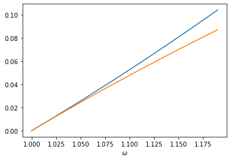

```python
omp = np.arange(1,1.2,0.01); z1 = (omp**2-1)/4; z2 = 0.5*np.log(omp)
plt.plot(omp, z1); plt.plot(omp, z2)
plt.xlabel(r'$\omega$')
plt.show()
```

Referências para aplicação de estados comprimidos em metrologia quântica, em particular na detecção de ondas gravitacionais:

- Grote, H.; Danzmann, K.; Dooley, K. L.; Schnabel, R.; Slutsky, J.; Vahlbruch, H. (2013). "First Long-Term Application of Squeezed States of Light in a Gravitational-Wave Observatory". https://arxiv.org/abs/1302.2188.
- The LIGO Scientific Collaboration (2011). "A gravitational wave observatory operating beyond the quantum shot-noise limit". https://arxiv.org/abs/1109.2295.
- Schnabel, Roman (2017). "Squeezed states of light and their applications in laser interferometers". https://arxiv.org/abs/1611.03986.

## Exercícios

1. Verifique que $$\langle n|(a^{\dagger})^{p}|n\rangle = \langle n|a^{p}|n\rangle = 0$$ para qualquer $n=0,1,2,\cdots$ e qualquer $p=1,2,3,\cdots$.
2. Verifique que $$\langle m|(a^{\dagger}+a)^{2}|n\rangle = \sqrt{(n+1)(n+2)}\delta_{m,n+2}+(2n+1)\delta_{m,n} + \sqrt{n(n-1)}\delta_{m,n-2}.$$
3. Verifique que $$|||n\rangle + |\psi_{n}^{(1)}\rangle||^{2} = 1 + 2\Big(\frac{\Delta\omega^{2}}{8\omega^{2}}\Big)^{2}(n(n+1)+1),$$ com $|\psi_{n}^{(1)}\rangle$ dado na eq. $(\star)$.
4. Verifique que $$\psi_{0'}(x) = \sqrt{\frac{1}{B\sqrt{\pi}}}e^{-x^{2}/2B^{2}}$$ com $B:= \sqrt{\frac{\hbar}{m\omega'}}.$
5. Verifique que \begin{align} & Var(X)_{0'} = \langle 0'|X^{2}|0'\rangle-\langle 0'|X|0'\rangle^{2} = \frac{\hbar}{2m\omega'} = B^{2}, \\ & Var(P)_{0'} = \langle 0'|P^{2}|0'\rangle-\langle 0'|P|0'\rangle^{2} = \frac{\hbar m\omega'}{2} = \frac{\hbar^{2}}{4B^{2}}, \end{align} e que portanto $$Var(X)_{0'}Var(P)_{0'} = \hbar^{2}/4.$$
6. Verifique que $$a^{\dagger}a^{\dagger}-aa = -\frac{i}{2\hbar}(XP+PX).$$
7. Verifique que \begin{align} & [a^{\dagger}a^{\dagger}-aa,a]=-2a^{\dagger}, \\ & [a^{\dagger}a^{\dagger}-aa,a^{\dagger}]=-2a. \end{align}